# FOXA1 regulates alternative splicing in prostate cancer

September 27, 2022

# *Authors*

Marco Del Giudice,John G. Foster, Serena Peirone , Alberto Rissone, Livia Caizzi, Federica Gaudino, Caterina Parlato, Francesca Anselmi, Rebecca Arkell, Simonetta Guarrera, Salvatore Oliviero, Giuseppe Basso, Prabhakar Rajan, and Matteo Cereda .

# *Introduction*

In this paper is revealed the crucial role of the pioneer transcription factor FOXA1 in prostate cancer. FOXA1 is a master regulator of alternative splicing and buffers the noise of isoform production toward a mRNA dominant isoform. This regulation impacts on splicing of nonsensemediated decay-determinant exons influencing patient survival.

# *Summary*

Dysregulation of alternative splicing in prostate cancer is linked to transcriptional programs activated by AR, ERG, FOXA1, and MYC. Of the TFs, we found that FOXA1 has the broadest influence of on regulatory regions of spliceosome genes across conditions, with the strongest involvement on proximal enhancers(including *HNRNPK* and *SRSF1*). FOXA1 is a pioneer transcription factor (TF), its role consists in opening chromatin to promote gene transcription and in regulating gene expression. Here, we show that FOXA1 functions as the primary orchestrator of alternative splicing dysregulation across 500 primary and metastatic prostate cancer transcriptomes. In prostate cancer, it coordinates its action with the androgen receptor (AR). Nevertheless it also possesses an AR-independent role of regulating epithelialto-mesenchymal transition (EMT). Our results indicate that FOXA1 lessens the noise of isoform production, in a consistent way across primary tumors, promoting the assembly of dominant isoforms in PC. This regulation especially impacts splicing factors themselves and leads to a reduction of nonsense-mediated decay (NMD)-targeted isoforms. We found a significantly higher inclusion of NMD-determinant *FLNA exon 30* in samples with high expression of both FOXA1 and *SRSF1*. This event promotes cell growth in vitro and predicts disease recurrence. Overall, we report a role for FOXA1 in orchestrating AS regulation in PC at different stages of gene expression in prostate cancer through a cascade of events from chromatin access, to splicing factor regulation, and, finally, to alternative splicing of exons influencing patient survival.

# *Figures*

## Figure *1.B*

Of the TFs, we found the most prevalent contribution of FOXA1 on regulatory regions of spliceosome genes across conditions, with the strongest involvement on proximal enhancers. These results corroborate the known contribution of AR, ERG, and MYC in AS regulation, while importantly revealing the broadest influence of FOXA1 (*green*) on the transcriptional control of spliceosome genes compared with the other TFs. Here, is shown the direct transcriptional control of each TF, we assessed the over-representation of genes with active TF-bound regulatory regions in a list of 186 KEGG canonical pathways. Furthermore, we found that FOXA1 preferentially bound enhancer (*blue*), over promoter (*yellow*), regions of differentially expressed SRGs.

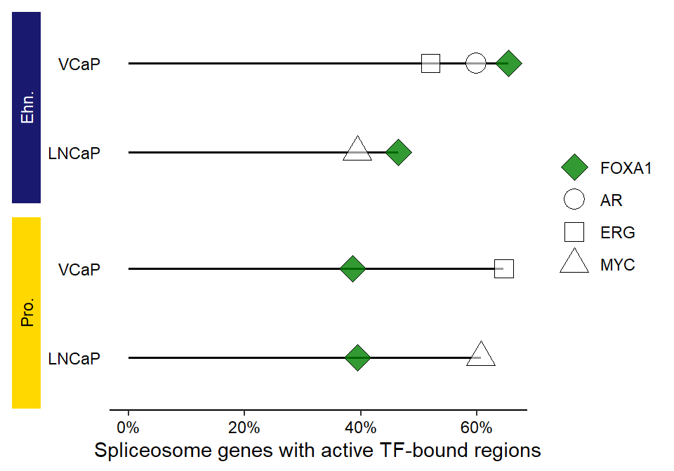

```r
V_cap<-as.data.frame(read_xlsx("/Users/admin/Desktop/R/Report/1-s2.0-S2211124722012414-mmc3.xlsx", sheet= 2, col_names= T, skip= 4))
Ln_cap<-as.data.frame(read_xlsx("/Users/admin/Desktop/R/Report/1-s2.0-S2211124722012414-mmc3.xlsx", sheet= 3, col_names= T, skip= 4))

Ln_cap$Line<-"LNCaP"
V_cap$Line<-"VCaP"



V_cap<-ddply(V_cap, .(Region, TF), mutate, rank=rank(FDR))
Ln_cap<-ddply(Ln_cap, .(Region, TF), mutate, rank=rank(FDR))

cap<-rbind(Ln_cap, V_cap)

kegg<-subset(cap, ID== "KEGG_SPLICEOSOME")
kegg_FDR<-subset(kegg, FDR<= 0.1 & rank<=5)
kegg_FDR$TF<-factor(kegg_FDR$TF, levels=c("FOXA1","AR","ERG","MYC"))

kegg_FDR$Ratio<-as.numeric(sapply(strsplit(kegg_FDR$GeneRatio, "/"), "[[", 1))/as.numeric(sapply(strsplit(kegg_FDR$`Background Ratio`, "/"), "[[",1))

strip<-strip_themed(text_y= elem_list_text(colour= list("white", "black")),background_y= elem_list_rect(fill = c("#191970", "#FFD800")))

kegg_FDR$Region[kegg_FDR$Region == "Promoter"] <- "Pro."
kegg_FDR$Region[kegg_FDR$Region == "Enhancer"] <- "Ehn."

plot_1B<-ggplot(kegg_FDR, aes(x= Ratio, y= Line))+
  geom_segment(aes(x= 0, y= Line, xend= Ratio, yend= Line), lwd= 0.7)+
  geom_point(aes(shape= TF, color=TF, fill=TF), size= 5, colour="black")+facet_wrap2(~ Region, ncol=1, nrow=2, strip.position= "left", strip=strip)+theme_classic()+
  scale_shape_manual(values=c(23, 21, 22, 24))+
  scale_fill_manual(values=c(alpha("#008000",0.8),alpha("white",0.6),alpha("white",0.6),alpha("white",0.6)))+xlab("Spliceosome genes with active TF-bound regions")+ylab(NULL)+theme(legend.title = element_blank(),strip.placement = "outside", strip.background = element_rect(colour = "white"), axis.line.y = element_blank(), axis.ticks.y = element_blank(), axis.text = element_text(color="black")) +scale_x_continuous(labels=percent)
plot_1B
```

## Figure *1.F*

We observed a significantly reduced expression of *HNRNPK* and *SRSF1* in the majority of PC cell lines upon FOXA1 depletion. Consistently, ectopic expression of FOXA1 protein in PC3 cells resulted in a significant increase in HNRNPK and SRSF1 expression compared with the control. This plot demonstrate that highly expressed FOXA1 increases the expression of splicing-related genes *SRGs*. In particular we focused our tests on *HNRNPK*, *HNRNPL* and *SRSF1*.

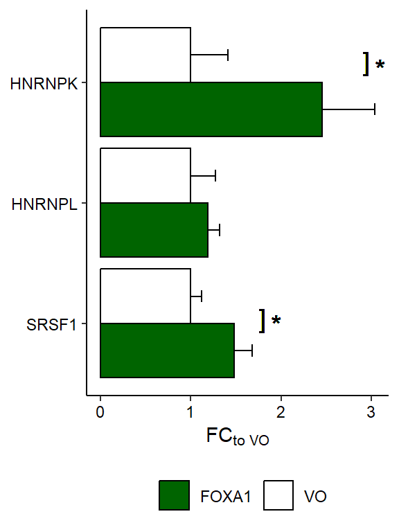

```r
plot_F<-read_excel("/Users/admin/Desktop/R/Report/1-s2.0-S2211124722012414-mmc4.xlsx", sheet=8)

plot_F<-plot_F[-1,]
colnames(plot_F)<- plot_F[1,]
plot_F<-plot_F[-1,]

plot_F$Symbol<- factor(plot_F$Symbol, levels = c("SRSF1", "HNRNPL", "HNRNPK"))
plot_F<-plot_F[order(plot_F$Symbol),]

plot_F$Mean<- as.numeric(plot_F$Mean)
plot_F$sd<- as.numeric(plot_F$sd)
plot_F$errore<-plot_F$sd+plot_F$Mean

plot_F$Condition[plot_F$Condition=="wt"]<- "VO"
plot_F$Condition[plot_F$Condition=="oe"]<- "FOXA1"

Plot<- ggplot(plot_F, aes(x=Symbol , y= Mean , fill=Condition))+geom_bar(stat="identity", position = "dodge", color="black")+theme_classic()+ geom_errorbar(aes(ymin=Mean, ymax=errore), width=.2, position=position_dodge(.9))+ylab(bquote(FC["to VO"]))+xlab(NULL)+ theme(legend.title = element_blank())+scale_fill_manual(values=c("FOXA1"="darkgreen", "VO"="white"))+ coord_flip() + theme(legend.position = "bottom", axis.text = element_text(colour = "black"))+geom_text(label="*",x = 3.12,y = 3.1, check_overlap = F,size=5)+geom_text(label="*",x = 1,y = 1.95, check_overlap = F,size=5)+geom_text(label="]",x = 1.05,y = 1.8, check_overlap = F,size=5)+geom_text(label="]",x = 3.18,y = 2.95, check_overlap = F,size=5)

Plot
```

## Figure *3.C* and *3.B*

Splicing factors can regulate their own mRNAs by controlling the inclusion of nonsense mediated decay (NMD)-determinant exons. By selectively including premature termination codon (PTC)-introducing and PTC-preventing exons, these transcripts can be targeted for degradation by NMD. Figure 3.B) Therefore, we sought to assess the regulation of NMD-determinant exons by FOXA1. Using a list of 15,518 NMD-determinant cassette exons (CEs), we found a significant enrichment of this class of exons among FOXA1-regulated exons. Figure 3C) By inspecting the distribution of mean inclusion changes in tumors with high FOXA1 expression compared with remaining ones, we found that FOXA1-regulated PTC-introducing CEs were significantly inhibited, whereas PTC-preventing events were significantly enhanced compared with controls. *These results suggest that FOXA1 predominantly calibrates AS toward dominant isoforms that escape NMD.*

### *3B*

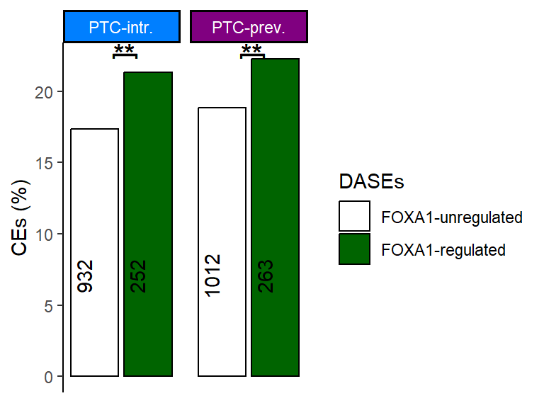

```r
B<-read.csv("/Users/admin/Desktop/R/Report/1-s2.0-S2211124722012414-mmc5csv.csv",head=T,sep=';', skip = 3)

tabella<-subset(B,exon_type=="FOXA1-unregulated"|exon_type=="FOXA1-regulated" & event_type=="ES")

l<-as.data.frame(table(tabella$exon_type, tabella$NMD.determinant))
l<-dcast(l, Var1~Var2, value.var = "Freq")
l$`PTC-intr.`<-l$`PTC-introducing`/(l$none+l$`PTC-preventing`+l$`PTC-introducing`)
l$`PTC-prev.`<-l$`PTC-preventing`/(l$none+l$`PTC-preventing`+l$`PTC-introducing`)

l$tot<-rowSums(l[, 2:4])

tabella1<-subset(tabella, NMD.determinant=="PTC-introducing"& exon_type=="FOXA1-unregulated" & event_type=="ES")

tabella2<-melt(data = l, id.vars = c("Var1", "none", "PTC-introducing", "PTC-preventing", "tot"))

tabella2$Var1<- factor(tabella2$Var1, levels = c("FOXA1-unregulated", "FOXA1-regulated"))
tabella2<-tabella2[order(tabella2$Var1),]

strip <- strip_themed(background_x = elem_list_rect(fill = c("#007FFF","#800080")))
colnames(tabella2)[1]<- "DASEs"

Plot_B<- ggplot(tabella2, aes(x=DASEs , y= value*100 , fill=DASEs))+geom_bar(stat="identity", position = "dodge", color="black")+theme_classic()+scale_fill_manual(values=c("FOXA1-regulated"="darkgreen", "FOXA1-unregulated"="white"))+ theme(legend.position = "bottom")+facet_wrap2(~variable, strip = strip) +ylab("CEs (%)")+ xlab(NULL)+theme(legend.position = "right",axis.line.x = element_blank(), axis.ticks.x = element_blank(), axis.text.x = element_blank())+ theme(strip.text = element_text(color = "white"))+ geom_text(aes(label=c("932", "1012", "252", "263"), y=7, angle=90), vjust=-0.2)+geom_text(label="**",x = 1.55,y = 22.7, check_overlap = F,size=5)+geom_text(label="]",x = 1.5,y = 22.5, check_overlap = F,size=5, angle=90)
Plot_B
```

### *3C*

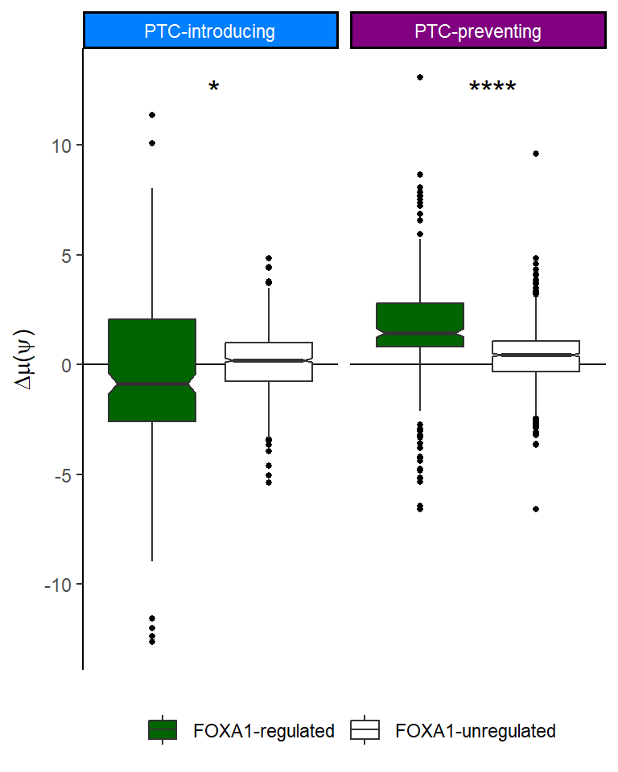

```r
C<-read_excel("/Users/admin/Desktop/R/Report/1-s2.0-S2211124722012414-mmc5.xlsx", sheet=3)
C<-C[-1,]
colnames(C)<- C[1,]
C<-C[-1,]
colnames(C)<- C[1,]
C<-C[-1,]
C<-subset(C, `NMD-determinant`!="none" & `NMD-determinant`!="NA")
C<- C[c("Ensembl_gene_ID","delta_PSI_median","delta_PSI_mean","delta_PSI_sd","exon_type","NMD-determinant")]

i<-c(2:4)
C[,i]<-apply(C[,i],2,function(x) as.numeric(x))

strip <- strip_themed(background_x = elem_list_rect(fill = c("#007FFF","#800080")))

tutto<-ggplot(C, aes(x=exon_type, y=delta_PSI_mean, fill= exon_type))+
  geom_hline(yintercept = 0)+ geom_boxplot(notch=TRUE,notchwidth = 0.8,outlier.colour="black",outlier.fill="black",outlier.size=1)+theme_classic()+scale_fill_manual(values=c("FOXA1-regulated"="darkgreen", "FOXA1-unregulated"="white"))+xlab(NULL)+ ylab(expression(paste(Delta, mu,"(",psi,")")))+theme(legend.position = "bottom",legend.title = element_blank(),axis.line.x = element_blank(), axis.ticks.x = element_blank(), axis.text.x = element_blank())+facet_wrap2(~`NMD-determinant`, strip = strip)+ theme(strip.text = element_text(color = "white"))+stat_compare_means(aes(group=exon_type),label="p.signif", label.x = 1.5, label.y = 12, cex=5)
tutto
```

### *Arranged*

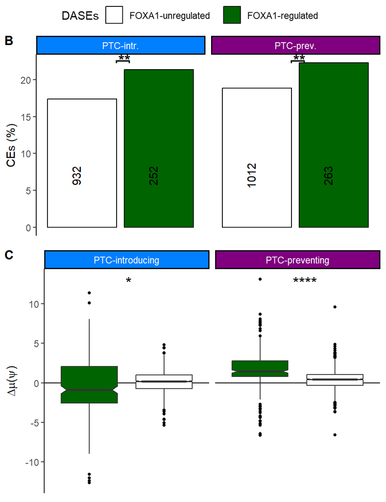

```r
ggarrange(Plot_B, tutto, nrow = 2, common.legend = T, labels = c("B", "C"), font.label = list(color="black", face="bold",size=12), heights = c(1,1.2), widths = c(1, 0.7))
```

## Figure *4.C*

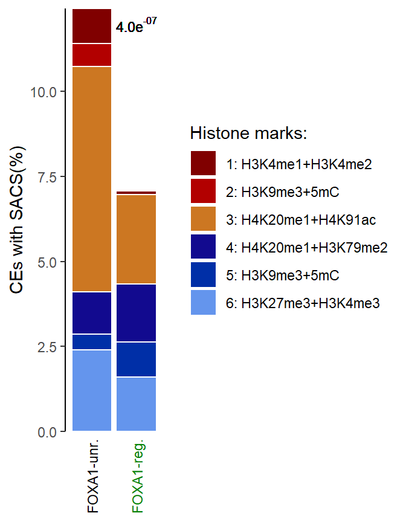

```r
D<-read.csv("/Users/admin/Desktop/R/Report/1-s2.0-S2211124722012414-mmc5-4.csv",head=T,sep=';', skip = 2)

G<-read.csv("/Users/admin/Desktop/R/Report/1-s2.0-S2211124722012414-mmc5conta.csv",head=T,sep=';', skip = 3)

D<-separate_rows(D,sacs_type, convert = T)
D<- subset(D, sacs_type!="NA")
tot_reg<-sum(G$exon_type=="FOXA1-regulated")
tot_unr<-sum(G$exon_type=="FOXA1-unregulated")

D$event_type= G$event_type[match(D$event_id,G$event_id)]

melt<-melt(table(D$sacs_type,D$ASE_set))
colnames(melt)<- c("sacs_type", "ASE_set", "value")


melt$perc[1:6]<- melt$value[1:6]/876
melt$perc[7:12]<- melt$value[7:12]/876

SACS<-ggplot(melt, aes(x=ASE_set , y= perc*100, fill=factor(sacs_type)))+geom_bar(stat="identity", position = "stack", color="white")+theme_classic()+ylab("CEs with SACS(%)")+xlab(NULL)+scale_x_discrete(labels=c("FOXA1-unr.", "FOXA1-reg."))+scale_fill_manual(values=c("1"="#800000", "2"="#B20000","3"="#CC7722", "4"="#120A8F","5"="#002FA7", "6"="#0F52BA","7"="#6495ED"),labels=c("1: H3K4me1+H3K4me2","2: H3K9me3+5mC","3: H4K20me1+H4K91ac", "4: H4K20me1+H3K79me2", "5: H3K9me3+5mC", "6: H3K27me3+H3K4me3", "7: H3K9ac+H3K14ac"))+theme(plot.title=element_text(hjust=0.5))+theme(axis.text.x = element_text(angle = 90, vjust = 0.5, hjust=0.5, color =c("FOXA1-unregulated"="black", "FOXA1_regulated"="#008000")), axis.line.x = element_blank(), axis.ticks.x = element_blank())+labs(fill="Histone marks:")+ scale_y_continuous(expand = c(0,0))+geom_text(label=expression("4.0e"^"-07"),parse = T,x = 2,y = 12, check_overlap = F,size=3)
SACS
```

## Figure *4.E*

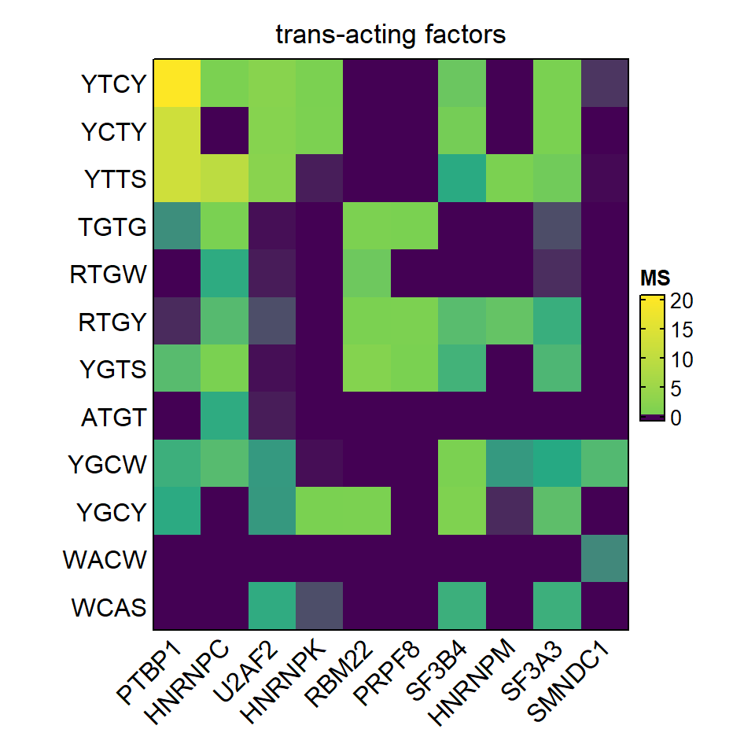

```r
top<-read_excel("/Users/admin/Desktop/R/Report/1-s2.0-S2211124722012414-mmc6.xlsx", sheet=3)
top<-top[-1,]
colnames(top)<- top[1,]
top<-top[-1,]

uniche<-unique(top$RBP)

heat<-read_excel("/Users/admin/Desktop/R/Report/1-s2.0-S2211124722012414-mmc6.xlsx", sheet=6)
heat<-heat[-1,]
colnames(heat)<- heat[1,]
heat<-heat[-1,]
colnames(heat)[1]<- "RBP"
unique<-subset(heat, RBP%in%uniche)

i<-c(2:14)
unique[,i]<-apply(unique[,i],2,function(x) as.numeric(x))

unique<- subset(unique, unique$RBP!="CDC40" & unique$RBP!="HNRNPU")
unique$RBP<- factor(unique$RBP, levels = c("PTBP1", "HNRNPC", "U2AF2","HNRNPK","RBM22", "PRPF8", "SF3B4","HNRNPM", "SF3A3", "SMNDC1"))
unique=unique[order(unique$RBP),]


colonne<-c("RBP","YTCY", "YCTY", "YTTS","TGTG","RTGW", "RTGY", "YGTS","ATGT", "YGCW", "YGCY", "WACW", "WCAS", "CTAA")
unique <- unique[,colonne]

map <- as.matrix(unique[,2:13])

map<-rescale(map, to = c(0, 20), from = range(map, na.rm = TRUE))

map<- t(map)
colnames(map)=unique$RBP
color <- colorRamp2(quantile(unlist(map), seq(0,1, 0.20)), colorRampPalette( viridis::viridis(6))(6))

a<-Heatmap(map, col=color,
        cluster_rows = FALSE,
        cluster_columns = FALSE,
        width=unit(0.8*ncol(map), "cm"),
        height=unit(0.8*nrow(map), "cm"),
        row_names_side = "left",
        column_title = "trans-acting factors",
        border = "black",
        border_gp = gpar(col = "black"),
        column_names_rot = 45,
        heatmap_legend_param = list(title = "MS", border="black"),
        )
a
```

## Figure *5.B*

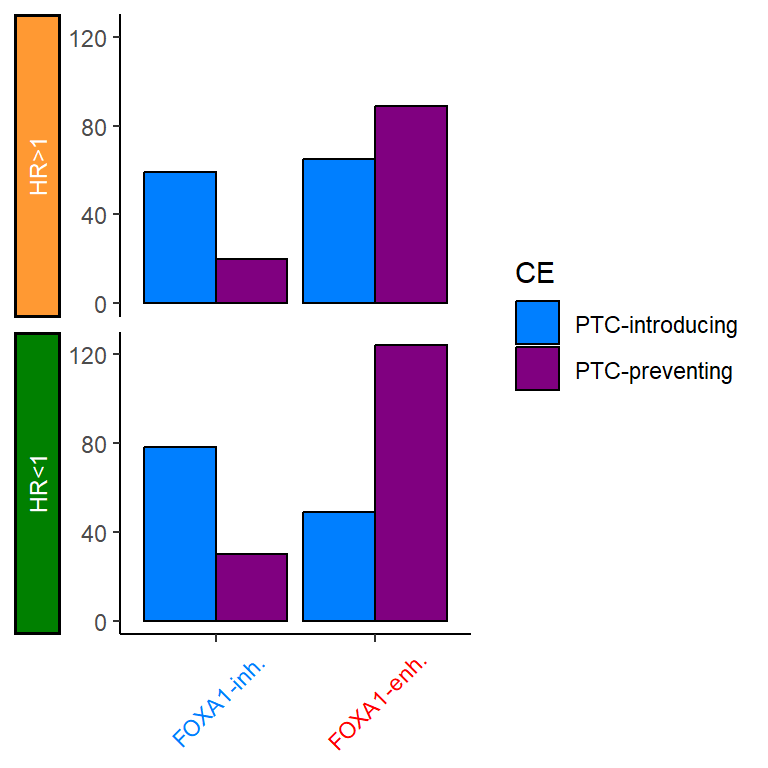

```r
fig5b<-read.csv("/Users/admin/Desktop/R/Report/1-s2.0-S2211124722012414-mmc5_foxareg.csv",header = TRUE,sep=';',skip=3, dec = ",")
fig5b_HR<-read.csv("/Users/admin/Desktop/R/Report/1-s2.0-S2211124722012414-mmc5-5.csv",header = TRUE,sep=';',skip=2, dec = ",")

fig5b_HR<-subset(fig5b_HR,hazard_ratio!="NA")

fig5b_merge<-subset(fig5b, event_id%in%fig5b_HR$event_id)

fig5b_merge$direction<-ifelse(fig5b_merge$delta_PSI_mean>0,"FOXA1-inh","FOXA1-enh")

fig5b_merge$hazard_ratio<- fig5b_HR$hazard_ratio

fig5b_merge$HR<-ifelse(fig5b_merge$hazard_ratio>1,"HR>1","HR<1")

fig5b_merge$HR<- factor(fig5b_merge$HR, levels = c("HR>1","HR<1"))
fig5b_merge<-fig5b_merge[order(fig5b_merge$HR),]

strip <- strip_themed(background_y = elem_list_rect(fill = c("#FF9933","#008000")))
colnames(fig5b_merge)[36]<- "CE"

Plot_5B<-ggplot(fig5b_merge, aes(x=direction,fill=CE))+theme_classic()+geom_bar(position = "dodge", color="black")+facet_wrap2(~HR,nrow = 2,ncol=1, strip = strip, strip.position = "left")+ ylab(NULL)+scale_x_discrete(labels = c("FOXA1-inh.", "FOXA1-enh."))+scale_fill_manual(values=c("PTC-introducing"="#007FFF", "PTC-preventing"="#800080"))+ xlab(NULL)+theme(plot.title=element_text(hjust=0.5))+theme(axis.text.x = element_text(angle = 45, vjust = 0.5, hjust=0.5, color =c("FOXA1-inh."="#007FFF", "FOXA1-enh."="red")),legend.position = "right", legend.direction = "vertical")+ theme(strip.text = element_text(color = "white"), strip.placement = "outside")
Plot_5B
```

## Figure *6.A*

Being the most harmful NMD-determinant exon associated with FOXA1 expression, we sought to investigate the impact of FLNA exon 30 on PC cell phenotypes. We observed a significant increase in growth and survival of cells overexpressing *FLNA+ex30* compared with the case for *FLNAΔ30*. These findings demonstrate that FLNA exon 30 inclusion is regulated by *SRSF*1, which is directly controlled by FOXA1. In conclusion, an increased expression of FLNA exon 30 confers a growth advantage to PC cells, which may drive poorer patient prognosis.

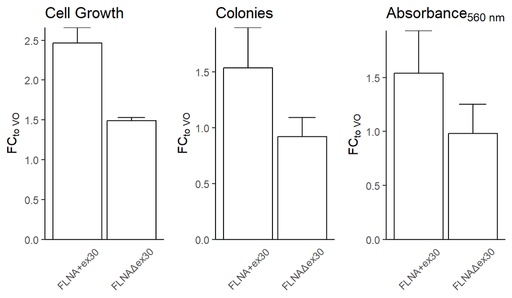

```r
left_6A<-as.data.frame(read.csv("/Users/admin/Desktop/R/Report/1-s2.0-S2211124722012414-mmc7left.csv", head=T, sep=';', skip=2, dec=","))

left_6A<-left_6A[c(2,3),]

plot_l<-ggplot(left_6A, aes(x=Condition, y=Mean)) + geom_bar(stat="identity", fill="white", col="black", names=names) + theme_classic() + ggtitle("Cell Growth") + ylab(bquote(FC["to VO"])) + geom_errorbar(aes(x=Condition, ymin=Mean, ymax=Mean+sd), width=0.5) +  scale_x_discrete(labels = c("FLNA+ex30", "FLNAΔex30")) + xlab(NULL) + theme(axis.text.x = element_text(angle = 45, vjust = 0.5), axis.ticks.x = element_blank())+ scale_y_continuous(expand = c(0,0))

centre_6A<-as.data.frame(read.csv("/Users/admin/Desktop/R/Report/1-s2.0-S2211124722012414-mmc7middle.csv", head=T, sep=';', skip=2, dec=","))

centre_6A<-centre_6A[c(2,3),]
plot_c<-ggplot(centre_6A, aes(x=Condition, y=Mean)) + geom_bar(stat="identity", fill="white", col="black") + theme_classic() + ggtitle("Colonies") + ylab(bquote(FC["to VO"])) + geom_errorbar( aes(x=Condition, ymin=Mean, ymax=Mean+sd),width=0.5) + scale_x_discrete(labels = c("FLNA+ex30", "FLNAΔex30")) + xlab(NULL) + theme(axis.text.x = element_text(angle = 45, vjust = 0.5), axis.ticks.x = element_blank())+ scale_y_continuous(expand = c(0,0))

right_6A<-as.data.frame(read.csv("/Users/admin/Desktop/R/Report/1-s2.0-S2211124722012414-mmc7right.csv", head=T, sep=';', skip=2, dec=","))

right_6A<-right_6A[c(2,3),]
plot_r<-ggplot(right_6A, aes(x=Condition, y=Mean)) + geom_bar(stat="identity", fill="white", col="black") + theme_classic() + ggtitle(bquote(Absorbance["560 nm"])) + ylab(bquote(FC["to VO"])) + geom_errorbar( aes(x=Condition, ymin=Mean, ymax=Mean+sd),width=0.5) + scale_x_discrete(labels = c("FLNA+ex30", "FLNAΔex30")) + xlab(NULL) + theme(axis.text.x = element_text(angle = 45, vjust = 0.5), axis.ticks.x = element_blank())+ scale_y_continuous(expand = c(0,0))

Plot_6<-ggarrange(plot_l, plot_c, plot_r, nrow = 1)
Plot_6
```

## Figure *S2.B*

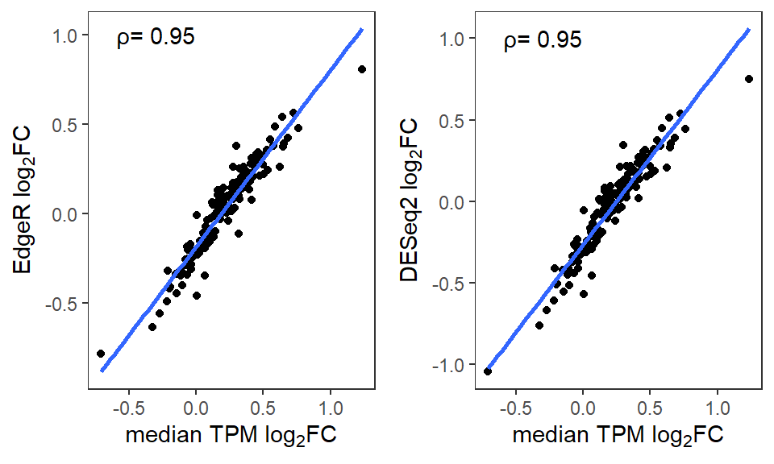

```r
S<-read_excel("/Users/admin/Desktop/R/Report/1-s2.0-S2211124722012414-mmc4.xlsx", sheet=2)
S<-S[-1,]
colnames(S)<- S[1,]
S<-S[-1,]

S<- S[c("Ensembl_id","L2R", "edgeR_logFC","DESeq2_log2FoldChange")]

i=c(2:4)
S[,i]<-apply(S[,i],2,function(x) as.numeric(x))

correlation1<-cor(S$L2R,S$edgeR_logFC,method="pearson")

primo<-ggplot(S, aes(x=L2R, y=edgeR_logFC))+geom_point()+geom_smooth(method ="lm", se=F)+ theme_bw()+theme(panel.grid = element_blank())+ annotate("text", x=-0.3,y=1,label=paste("ρ=",round(correlation1,2)))+labs(x=expression('median TPM log'[2]*'FC'),y=expression('EdgeR log'[2]*'FC'))

correlation2<-cor(S$L2R,S$DESeq2_log2FoldChange,method="pearson")

secondo<-ggplot(S, aes(x=L2R, y=DESeq2_log2FoldChange))+geom_point()+geom_smooth(method ="lm", se=F)+ theme_bw()+theme(panel.grid = element_blank())+annotate("text",x=-0.3,y=1,label=paste("ρ=",round(correlation2,2)))+labs(x=expression('median TPM log'[2]*'FC'),y=expression('DESeq2 log'[2]*'FC'))

insieme<-ggarrange(primo, secondo, widths = 1, heights = 1)
insieme
```

## Figure *S2.I*

This is a bar plots showing the fractions of FOXA1-regulated SRGs in primary PCs and mCRPCs that changed in expression upon FOXA1 depletion in VCaP and PC3 cells. Most of SRGs were concordantly regulated by FOXA1 in both cell lines to a similar magnitude to primary PCs and mCRPCs. Consistent with the metastatic origin of the cell lines, a higher number of differentially expressed SRGs in mCRPCs were concordantly up-regulated in the cell lines than the SRGs that were DE in primary PC. On average, 76% of the FOXA1-regulated SRGs in primary PCs and/or mCRPCs were concordantly regulated by FOXA1 in the two cell lines.

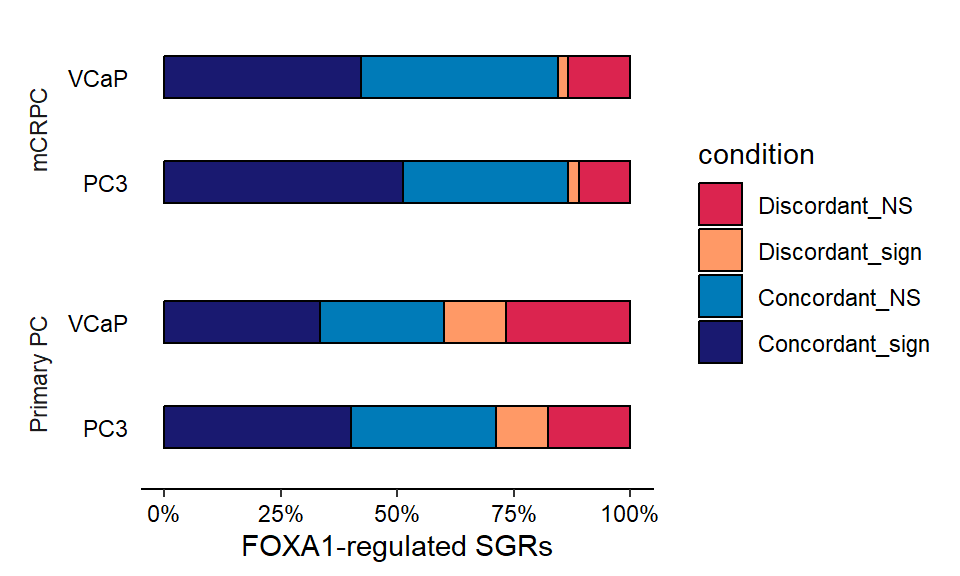

```r
S2I<-as.data.frame(read_xlsx("/Users/admin/Desktop/R/Report/1-s2.0-S2211124722012414-mmc4.xlsx", sheet=4, skip = 4))

tab<-function(f){

  f$concordant<-c("Discordant","Concordant")[as.numeric(f$Same_direction_public)+1]
  f$fdr<-c("NS","sign")[as.numeric(f$Sign)+1]

  t<-(table(f$concordant,f$fdr))

  ret<-reshape2::melt(t)

  colnames(ret)<-c("Concordant","FDR","value")

  return(ret)
}


fig<-rbind.data.frame()
for (i in unique(S2I$Cancer)) {
  for(j in unique(S2I$Cell_line)){
    tmp<-tab(subset(S2I, Cancer==i & Cell_line==j))
    tmp$Cancer<-i
    tmp$Cell_line<-j
    fig<-rbind.data.frame(fig, tmp)
  }
}


fig$condition<-paste0(fig$Concordant,"_",fig$FDR)
fig$condition<-factor(as.character(fig$condition),levels = rev(c("Concordant_sign","Concordant_NS","Discordant_sign","Discordant_NS")))

fig$Cancer[fig$Cancer == "P"] <- "Primary PC"
fig$Cancer[fig$Cancer == "M"] <- "mCRPC"


ggplot(fig, aes(x=Cell_line, y=value, fill=condition))+ geom_bar(stat = "identity", position = "fill", width = 0.4, color="black")+ coord_flip()+ facet_grid(Cancer~.,switch = "y")+theme_classic()+ xlab(NULL)+ylab("FOXA1-regulated SGRs")+scale_y_continuous(labels=percent)+theme( axis.ticks.y = element_blank(), axis.line.y = element_blank(), axis.text = element_text(color = "black"), strip.placement = "outside", strip.background = element_blank())+scale_fill_manual(values=c("Discordant_NS"="#DB244F", "Discordant_sign"="#FF9966", "Concordant_NS"="#007BB8", "Concordant_sign"="#191970"))
```